# Reproducible Research: Peer Assessment 1

## Loading and preprocessing the data

First: Read the file into a variable. Assume activity.zip file is in working directory. “unz” will unzip the file

```r
s<- read.table(unz('activity.zip','activity.csv'), header=T, quote="\"", sep=",")
```

File is already in a suitable format for analysis

## What is mean total number of steps taken per day?

Total Steps each day:

```r
aggregate(steps~date,data=s,FUN=sum)
```

```
##          date steps
## 1  2012-10-02   126
## 2  2012-10-03 11352
## 3  2012-10-04 12116
## 4  2012-10-05 13294
## 5  2012-10-06 15420
## 6  2012-10-07 11015
## 7  2012-10-09 12811
## 8  2012-10-10  9900
## 9  2012-10-11 10304
## 10 2012-10-12 17382
## 11 2012-10-13 12426
## 12 2012-10-14 15098
## 13 2012-10-15 10139
## 14 2012-10-16 15084
```

[output cut: 39 more lines]

Histogram of the steps per day:

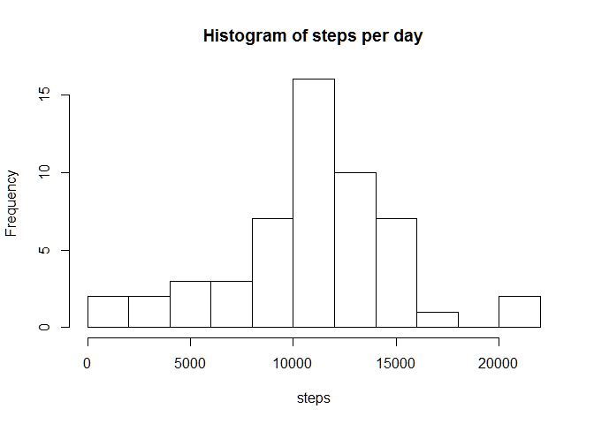

```r
perDay<-aggregate(steps~date,data=s,FUN=sum)
hist(perDay$steps, breaks=10, main="Histogram of steps per day", xlab="steps")
```

Mean of total steps for each day:

```r
mean(perDay$steps)
```

```
## [1] 10766.19
```

Median of total steps per day:

```r
median(perDay$steps)
```

```
## [1] 10765
```

## What is the average daily activity pattern?

Calculate the average steps for each 5 minute interval and plot the results:

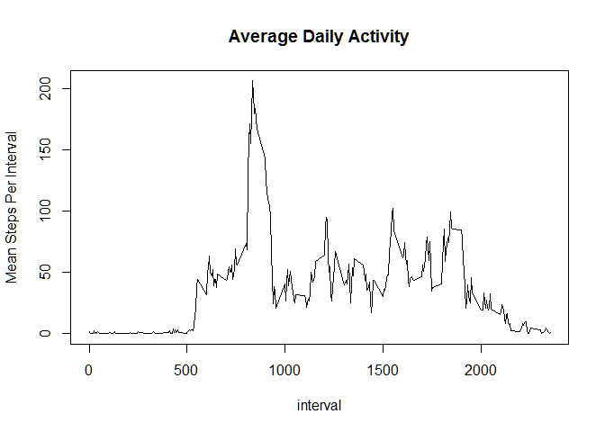

```r
perMin<-aggregate(steps~interval,data=s,FUN=mean)
plot(perMin,ylab="Mean Steps Per Interval", main="Average Daily Activity", type="l")
```

Find interval with biggest average steps:

```r
BigAvg<- perMin[perMin$steps==max(perMin$steps),]$interval
```

The value of BigAvg is printed inline on the next line:

Interval number 835 has the largest average

## Imputing missing values

How many rows have missing values?

```r
nrow(s[is.na(s$steps),])
```

```
## [1] 2304
```

To impute missing values we will replace NA with the average value for that interval.

merge s and perMin and then update any NA values in steps with the average interval value

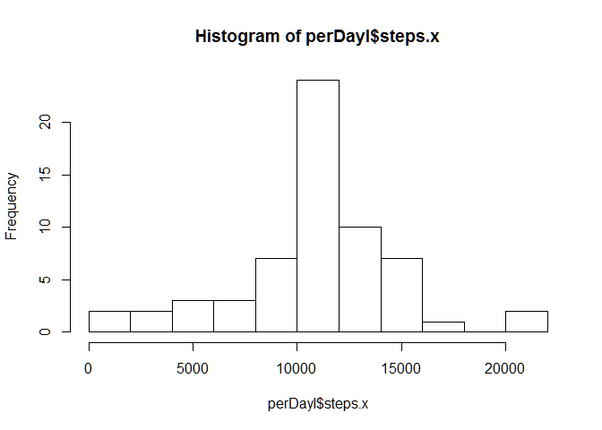

```r
sI<-merge(x=s,y=perMin,by="interval")
for(i in 1:nrow(sI)){ if(is.na(sI[i,]$steps.x)) sI[i,]$steps.x = sI[i,]$steps.y}

perDayI<-aggregate(steps.x~date,data=sI,FUN=sum)
hist(perDayI$steps.x,breaks=10)
```

Not much impact when fixing missing values…

Mean with imputed data:

```r
mean(perDayI$steps.x)
```

```
## [1] 10766.19
```

Median with imputed data:

```r
median(perDayI$steps.x)
```

```
## [1] 10766.19
```

There is basically no difference between the mean with the original data and the mean with the imputed data

## Are there differences in activity patterns between weekdays and weekends?

Code dates as weekdays or weekends:

```r
sI$dayType='unknown'
for(i in 1:nrow(sI)){ if(weekdays(as.POSIXct(sI[i,]$date)) %in% c('Saturday','Sunday')) {sI[i,]$dayType='weekend'}else {sI[i,]$dayType='weekday'}}
```

Get interval averages for weekdays and for weekends:

```r
perMinIWeekday<-aggregate(steps.x~interval,data=sI[sI$dayType=='weekday',], FUN=mean)
perMinWeekend<- aggregate(steps.x~interval,data=sI[sI$dayType=='weekend',], FUN=mean)
```

Plot the datasets:

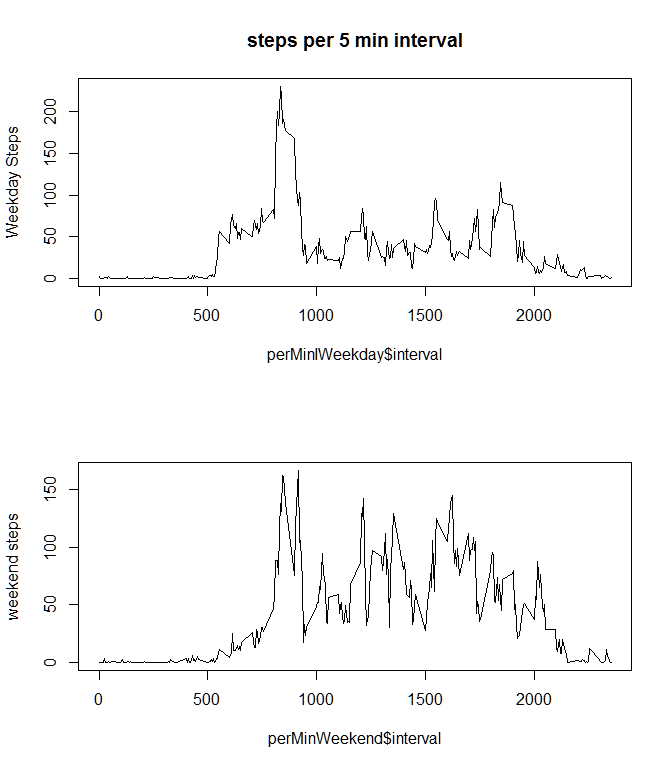

```r
par(mfcol=c(2,1))
plot(perMinIWeekday$interval,perMinIWeekday$steps.x, type="l", ylab="Weekday Steps", main="steps per 5 min interval")
plot(perMinWeekend$interval,perMinWeekend$steps.x, type="l", ylab="weekend steps")
```